# Module 07b — What these studies actually found, and where the holes are

HWC North Africa automated evidence map

2026-08-24

```r
knitr::opts_chunk$set(echo = TRUE, warning = TRUE, message = TRUE, dpi = 300)
suppressPackageStartupMessages({
  library(here); library(dplyr); library(tibble); library(readr)
  library(ggplot2); library(tidyr)
})
source(here::here("R", "config.R"))
source(here::here("R", "species_reference.R"))
OKABE <- c("#E69F00", "#56B4E9", "#009E73", "#F0E442", "#0072B2", "#D55E00", "#CC79A7")
save_fig <- function(p, name, w = 8, h = 5) {
  dir.create(here::here(DIR_FIGURES), showWarnings = FALSE, recursive = TRUE)
  ggsave(here::here(DIR_FIGURES, paste0(name, ".png")), p, width = w, height = h, dpi = 300)
  ggsave(here::here(DIR_FIGURES, paste0(name, ".svg")), p, width = w, height = h)
  p
}
save_tab <- function(d, name) {
  dir.create(here::here(DIR_TABLES), showWarnings = FALSE, recursive = TRUE)
  readr::write_csv(d, here::here(DIR_TABLES, paste0(name, ".csv"))); d
}
```

```r
man   <- readRDS(here::here(DIR_DERIVED, "extraction_manifest.rds"))
stopifnot(isTRUE(man$complete))
ext   <- readRDS(here::here(DIR_DERIVED, "extraction_fields.rds"))
rel   <- readr::read_csv(here::here(DIR_TABLES, "extraction_reliability.csv"),
                         show_col_types = FALSE)
attr_ <- readRDS(here::here(DIR_DERIVED, "country_attribution.rds"))
tiers <- readRDS(here::here(DIR_DERIVED, "geography_tiers.rds"))
ledg  <- readRDS(here::here(DIR_DERIVED, "dedup_ledger.rds")) |>
  dplyr::distinct(id, .keep_all = TRUE)
unreliable <- rel$field[!rel$reliable %in% TRUE]

# Schema-echo junk. The field spec literally reads `mitigation_type: free
# text, or "not stated"`, and the model occasionally returned the string
# "free text" as the value. These are prompt artefacts, not extractions, and
# are dropped here and counted so the defect is visible rather than silent.
JUNK <- c("free text", "n/a", "na", "none", "unknown", "not applicable")
n_junk <- sum(tolower(trimws(ext$value_final)) %in% JUNK, na.rm = TRUE)

val <- function(f) {
  ext |>
    dplyr::filter(field == f, !is.na(value_final), value_final != "not stated",
                  !(tolower(trimws(value_final)) %in% JUNK)) |>
    dplyr::select(id, value = value_final, evidence_base)
}

countries_long <- attr_ |>
  dplyr::select(id, dplyr::all_of(COUNTRIES)) |>
  tidyr::pivot_longer(-id, names_to = "country", values_to = "covered") |>
  dplyr::filter(covered %in% TRUE) |>
  dplyr::select(id, country)

ta <- ledg |>
  dplyr::filter(id %in% tiers$id[tiers$analytic]) |>
  dplyr::transmute(id, text = tolower(paste(title, dplyr::coalesce(abstract, ""))))
n_map <- NROW(ta)
```

3 extracted values were the literal schema instruction (“free text”) rather than a value. They are dropped from everything below and reported here because a prompt defect that silently becomes data is worse than one that is counted.

# 1 The map proper: conflict type by country

Marginal counts say how much research exists. They do not say **what is studied where**, which is what a reader planning work in Libya actually needs. Every cell below is printed, including the zeros — that is the point of the table.

```r
ct <- val("conflict_type") |> dplyr::inner_join(countries_long, by = "id")
ct_mat <- ct |>
  dplyr::count(value, country) |>
  tidyr::pivot_wider(names_from = country, values_from = n, values_fill = 0L) |>
  dplyr::mutate(total = rowSums(dplyr::across(dplyr::any_of(COUNTRIES)))) |>
  dplyr::arrange(dplyr::desc(total))
# Force every country column to exist even if no study populated it.
for (cn in setdiff(COUNTRIES, names(ct_mat))) ct_mat[[cn]] <- 0L
ct_mat <- ct_mat |> dplyr::select(conflict_type = value, dplyr::all_of(COUNTRIES), total)
knitr::kable(ct_mat, caption = "Conflict type by country. Counts are study-country pairs; a study spanning three countries appears in three columns.")
```

Conflict type by country. Counts are study-country pairs; a study spanning three countries appears in three columns.

| conflict_type | Tunisia | Algeria | Morocco | Libya | Egypt | total |
| --- | --- | --- | --- | --- | --- | --- |
| bycatch | 31 | 7 | 10 | 12 | 17 | 77 |
| other | 5 | 2 | 9 | 0 | 6 | 22 |
| competition for resources | 2 | 5 | 6 | 1 | 2 | 16 |
| crop damage | 2 | 2 | 2 | 1 | 9 | 16 |
| persecution or retaliatory killing | 3 | 4 | 3 | 2 | 3 | 15 |
| attacks on humans | 0 | 0 | 1 | 0 | 1 | 2 |
| disease transmission | 0 | 0 | 2 | 0 | 0 | 2 |
| property damage | 0 | 0 | 0 | 1 | 1 | 2 |
| livestock depredation | 0 | 0 | 1 | 0 | 0 | 1 |

```r
save_tab(ct_mat, "07b_conflict_by_country")
```

```
## # A tibble: 9 × 7
##   conflict_type                      Tunisia Algeria Morocco Libya Egypt total
##   <chr>                                <int>   <int>   <int> <int> <int> <dbl>
## 1 bycatch                                 31       7      10    12    17    77
## 2 other                                    5       2       9     0     6    22
## 3 competition for resources                2       5       6     1     2    16
## 4 crop damage                              2       2       2     1     9    16
## 5 persecution or retaliatory killing       3       4       3     2     3    15
## 6 attacks on humans                        0       0       1     0     1     2
## 7 disease transmission                     0       0       2     0     0     2
## 8 property damage                          0       0       0     1     1     2
## 9 livestock depredation                    0       0       1     0     0     1
```

```r
zeros <- ct_mat |>
  tidyr::pivot_longer(dplyr::all_of(COUNTRIES), names_to = "country", values_to = "n") |>
  dplyr::filter(n == 0)
n_cells <- NROW(ct_mat) * length(COUNTRIES)
```

**15 of 45 conflict-type × country cells are empty** (33%), and the occupied cells are highly uneven: the largest holds 77 study-country pairs while 4 of the 9 conflict types have two or fewer across the whole region.

```r
# Types documented in one country and absent in a neighbour. Restricted to
# types with enough studies overall that absence is informative rather than a
# reflection of the type being rare everywhere.
asym <- ct_mat |>
  dplyr::filter(total >= 5) |>
  tidyr::pivot_longer(dplyr::all_of(COUNTRIES), names_to = "country", values_to = "n") |>
  dplyr::group_by(conflict_type) |>
  dplyr::filter(any(n == 0) & any(n >= 3)) |>
  dplyr::summarise(
    studied_in = paste(sprintf("%s (%d)", country[n >= 3], n[n >= 3]), collapse = ", "),
    absent_in  = paste(country[n == 0], collapse = ", "),
    .groups = "drop")
knitr::kable(asym, caption = "Conflict types documented in at least one country and wholly absent in another")
```

Conflict types documented in at least one country and wholly absent in another

| conflict_type | studied_in | absent_in |
| --- | --- | --- |
| other | Tunisia (5), Morocco (9), Egypt (6) | Libya |

```r
save_tab(asym, "07b_conflict_asymmetry")
```

```
## # A tibble: 1 × 3
##   conflict_type studied_in                          absent_in
##   <chr>         <chr>                               <chr>
## 1 other         Tunisia (5), Morocco (9), Egypt (6) Libya
```

These asymmetries are the map’s most actionable output **and its most treacherous**. An ecologically implausible absence — a conflict type well documented in Tunisia and absent in Algeria, which share the same Atlas systems, fauna and farming — is far more likely to reflect our search than the ecology. Each row is a research question, not a conclusion.

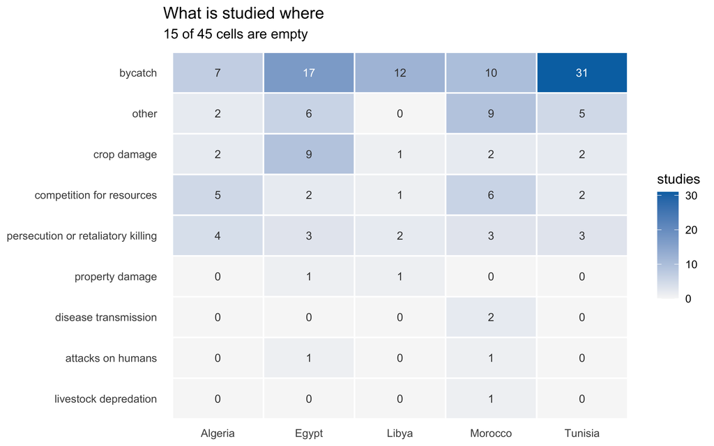

```r
p <- ct |> dplyr::count(value, country) |>
  tidyr::complete(value, country = COUNTRIES, fill = list(n = 0L)) |>
  ggplot(aes(x = country, y = reorder(value, n, sum), fill = n)) +
  geom_tile(colour = "white", linewidth = 0.6) +
  geom_text(aes(label = n, colour = n > 12), size = 3.2, show.legend = FALSE) +
  scale_fill_gradient(low = "#F7F7F7", high = OKABE[5], name = "studies") +
  scale_colour_manual(values = c("grey25", "white")) +
  labs(x = NULL, y = NULL, title = "What is studied where",
       subtitle = sprintf("%d of %d cells are empty", NROW(zeros), n_cells)) +
  theme_minimal(base_size = 11) + theme(panel.grid = element_blank())
save_fig(p, "07b_conflict_by_country", 8, 5)
```

# 2 Species with documented conflict and zero studies

```r
sp_ext <- val("species_common") |> dplyr::select(id, sp = value)

ref <- SPECIES_REFERENCE |>
  dplyr::rowwise() |>
  dplyr::mutate(
    pat = species_pattern(scientific),
    ids = list(unique(c(
      ta$id[grepl(pat, ta$text)],
      sp_ext$id[grepl(pat, tolower(sp_ext$sp))])))) |>
  dplyr::ungroup() |>
  dplyr::mutate(studies = lengths(ids))

ref_tbl <- ref |>
  dplyr::select(scientific, common, conflict_context, studies) |>
  dplyr::arrange(studies, scientific)
knitr::kable(ref_tbl, caption = "The eleven taxa the protocol named as plausibly involved in regional conflict, frozen before the search ran")
```

The eleven taxa the protocol named as plausibly involved in regional conflict, frozen before the search ran

| scientific | common | conflict_context | studies |
| --- | --- | --- | --- |
| Canis lupaster | African wolf | livestock depredation | 0 |
| Hystrix cristata | crested porcupine | crop damage | 0 |
| Vulpes zerda | fennec fox | persecution, trade | 0 |
| Ammotragus lervia | aoudad | hunting, competition | 1 |
| Canis aureus | golden jackal | livestock depredation | 1 |
| Hyaena hyaena | striped hyaena | livestock depredation, persecution | 1 |
| Monachus monachus | Mediterranean monk seal | fisheries interaction | 1 |
| Gazella dorcas | dorcas gazelle | hunting, competition | 2 |
| Sus scrofa | wild boar | crop damage | 7 |
| Macaca sylvanus | Barbary macaque | crop damage, tourism conflict | 13 |
| Caretta caretta | loggerhead turtle | fisheries bycatch | 29 |

```r
save_tab(ref_tbl, "07b_species_reference_coverage")
```

```
## # A tibble: 11 × 4
##    scientific        common                  conflict_context            studies
##    <chr>             <chr>                   <chr>                         <int>
##  1 Canis lupaster    African wolf            livestock depredation             0
##  2 Hystrix cristata  crested porcupine       crop damage                       0
##  3 Vulpes zerda      fennec fox              persecution, trade                0
##  4 Ammotragus lervia aoudad                  hunting, competition              1
##  5 Canis aureus      golden jackal           livestock depredation             1
##  6 Hyaena hyaena     striped hyaena          livestock depredation, per…       1
##  7 Monachus monachus Mediterranean monk seal fisheries interaction             1
##  8 Gazella dorcas    dorcas gazelle          hunting, competition              2
##  9 Sus scrofa        wild boar               crop damage                       7
## 10 Macaca sylvanus   Barbary macaque         crop damage, tourism confl…      13
## 11 Caretta caretta   loggerhead turtle       fisheries bycatch                29
```

```r
zero_sp <- ref_tbl |> dplyr::filter(studies == 0)
thin_sp <- ref_tbl |> dplyr::filter(studies > 0, studies <= 3)
```

This reference set is **pre-specified**: it is the eleven binomials written into the search string in Module 01, before any record was retrieved. The search actively looked for every one of them, so a species with no studies is one the search sought and did not find — not one we noticed was missing after the fact.

**3 of the eleven have zero studies: *Canis lupaster* (African wolf), *Hystrix cristata* (crested porcupine), *Vulpes zerda* (fennec fox).**

A further 5 are represented by three studies or fewer: *Ammotragus lervia* (aoudad, n=1), *Canis aureus* (golden jackal, n=1), *Hyaena hyaena* (striped hyaena, n=1), *Monachus monachus* (Mediterranean monk seal, n=1), *Gazella dorcas* (dorcas gazelle, n=2). At that depth a single additional study would materially change what is known.

```r
# Every reference taxon must appear, including the ones with no studies at
# all: a species that drops out of the join is precisely the finding this
# table exists to report. Built by completing against the full reference set
# rather than by joining and hoping.
sp_country <- ref |>
  dplyr::select(scientific, common, ids) |>
  tidyr::unnest(ids, keep_empty = TRUE) |>
  dplyr::rename(id = ids) |>
  dplyr::left_join(countries_long, by = "id", relationship = "many-to-many") |>
  dplyr::filter(!is.na(country)) |>
  dplyr::count(scientific, common, country) |>
  tidyr::complete(tidyr::nesting(scientific, common), country = COUNTRIES,
                  fill = list(n = 0L)) |>
  tidyr::pivot_wider(names_from = country, values_from = n, values_fill = 0L) |>
  dplyr::right_join(SPECIES_REFERENCE |> dplyr::select(scientific, common),
                    by = c("scientific", "common")) |>
  dplyr::mutate(dplyr::across(dplyr::any_of(COUNTRIES), ~ tidyr::replace_na(.x, 0L)))
for (cn in setdiff(COUNTRIES, names(sp_country))) sp_country[[cn]] <- 0L
sp_country <- sp_country |>
  dplyr::select(scientific, common, dplyr::all_of(COUNTRIES)) |>
  dplyr::mutate(total = rowSums(dplyr::across(dplyr::all_of(COUNTRIES)))) |>
  dplyr::arrange(dplyr::desc(total))
stopifnot(NROW(sp_country) == NROW(SPECIES_REFERENCE))
knitr::kable(sp_country, caption = "Reference taxa by country: the species-level evidence map, zeros included")
```

Reference taxa by country: the species-level evidence map, zeros included

| scientific | common | Tunisia | Algeria | Morocco | Libya | Egypt | total |
| --- | --- | --- | --- | --- | --- | --- | --- |
| Caretta caretta | loggerhead turtle | 19 | 5 | 3 | 5 | 5 | 37 |
| Macaca sylvanus | Barbary macaque | 1 | 5 | 11 | 0 | 0 | 17 |
| Sus scrofa | wild boar | 1 | 0 | 3 | 1 | 1 | 6 |
| Hyaena hyaena | striped hyaena | 1 | 1 | 1 | 1 | 1 | 5 |
| Gazella dorcas | dorcas gazelle | 1 | 1 | 1 | 0 | 0 | 3 |
| Ammotragus lervia | aoudad | 1 | 1 | 0 | 0 | 0 | 2 |
| Canis aureus | golden jackal | 0 | 0 | 1 | 0 | 0 | 1 |
| Monachus monachus | Mediterranean monk seal | 1 | 0 | 0 | 0 | 0 | 1 |
| Canis lupaster | African wolf | 0 | 0 | 0 | 0 | 0 | 0 |
| Hystrix cristata | crested porcupine | 0 | 0 | 0 | 0 | 0 | 0 |
| Vulpes zerda | fennec fox | 0 | 0 | 0 | 0 | 0 | 0 |

```r
save_tab(sp_country, "07b_species_by_country")
```

```
## # A tibble: 11 × 8
##    scientific        common            Tunisia Algeria Morocco Libya Egypt total
##    <chr>             <chr>               <int>   <int>   <int> <int> <int> <dbl>
##  1 Caretta caretta   loggerhead turtle      19       5       3     5     5    37
##  2 Macaca sylvanus   Barbary macaque         1       5      11     0     0    17
##  3 Sus scrofa        wild boar               1       0       3     1     1     6
##  4 Hyaena hyaena     striped hyaena          1       1       1     1     1     5
##  5 Gazella dorcas    dorcas gazelle          1       1       1     0     0     3
##  6 Ammotragus lervia aoudad                  1       1       0     0     0     2
##  7 Canis aureus      golden jackal           0       0       1     0     0     1
##  8 Monachus monachus Mediterranean mo…       1       0       0     0     0     1
##  9 Canis lupaster    African wolf            0       0       0     0     0     0
## 10 Hystrix cristata  crested porcupine       0       0       0     0     0     0
## 11 Vulpes zerda      fennec fox              0       0       0     0     0     0
```

```r
sp_zero_cells <- sum(sp_country |> dplyr::select(dplyr::all_of(COUNTRIES)) == 0)
```

**31 of 55 species × country cells are empty.** For taxa the protocol itself flagged as regionally conflict-prone, that is the sharpest statement of the gap this map can make.

# 3 Did anything work? The mitigation evidence

```r
mo  <- val("mitigation_outcome_measured")
od  <- val("outcome_direction")
mt  <- val("mitigation_type")
mtd <- val("mitigation_tested")
n_measured <- sum(mo$value == "yes")
```

```r
funnel <- tibble::tibble(
  stage = c("studies in the map",
            "state whether a mitigation was tested",
            "a mitigation was tested",
            "state whether its outcome was measured",
            "outcome was measured",
            "report a direction of effect"),
  n = c(n_map, NROW(mtd), sum(mtd$value == "yes"), NROW(mo), n_measured,
        sum(od$value != "not measured")))
knitr::kable(funnel, caption = "The intervention-evidence funnel")
```

The intervention-evidence funnel

| stage | n |
| --- | --- |
| studies in the map | 262 |
| state whether a mitigation was tested | 103 |
| a mitigation was tested | 38 |
| state whether its outcome was measured | 89 |
| outcome was measured | 27 |
| report a direction of effect | 22 |

```r
save_tab(funnel, "07b_mitigation_funnel")
```

```
## # A tibble: 6 × 2
##   stage                                      n
##   <chr>                                  <int>
## 1 studies in the map                       262
## 2 state whether a mitigation was tested    103
## 3 a mitigation was tested                   38
## 4 state whether its outcome was measured    89
## 5 outcome was measured                      27
## 6 report a direction of effect              22
```

```r
dir_tbl <- od |> dplyr::count(value, sort = TRUE) |>
  dplyr::rename(outcome_direction = value, studies = n)
knitr::kable(dir_tbl, caption = "Direction of effect, where a direction was reported")
```

Direction of effect, where a direction was reported

| outcome_direction | studies |
| --- | --- |
| not measured | 43 |
| reduced conflict | 19 |
| increased conflict | 2 |
| mixed | 1 |

```r
save_tab(dir_tbl, "07b_outcome_direction")
```

```
## # A tibble: 4 × 2
##   outcome_direction  studies
##   <chr>                <int>
## 1 not measured            43
## 2 reduced conflict        19
## 3 increased conflict       2
## 4 mixed                    1
```

```r
n_reduced <- sum(od$value == "reduced conflict")
n_notmeas <- sum(od$value == "not measured")
```

Of the 65 studies that reported an outcome direction at all, **43 say the outcome was not measured** and 19 report reduced conflict, against 2 reporting increased conflict and 1 mixed.

**Read the 19 “reduced conflict” results with care.** They are not 19 demonstrations that something works. Nothing here distinguishes a controlled evaluation from an author stating that a measure helped, and positive results are far likelier to be written up than null ones. What the map can defend is the *shape* of the funnel: interventions are described far more often than they are evaluated.

```r
mt_tbl <- mt |>
  dplyr::mutate(value = dplyr::if_else(nchar(value) > 90,
                                       paste0(substr(value, 1, 87), "..."), value)) |>
  dplyr::arrange(value) |>
  dplyr::select(mitigation = value, evidence_base)
knitr::kable(mt_tbl, caption = "Every mitigation described in the corpus, as extracted")
```

Every mitigation described in the corpus, as extracted

| mitigation | evidence_base |
| --- | --- |
| An integrated bird risk management system has been followed and implemented in airports… | title_abstract |
| Djobs traditional water storage system (mobilizing and storing surface water) | title_abstract |
| Flexible Turtle Excluder Device (TED) | title_abstract |
| Mechanical and chemical control using fine net and three pesticides (Methomyl, Zinc pho… | title_abstract |
| Nature-Based Solutions (NbSs), on the other hand, are increasingly recognized for addre… | title_abstract |
| New technologies that can mitigate the bycatch of vulnerable species | title_abstract |
| Swordfish buoy gear as an alternative to pelagic driftnets | title_abstract |
| Toxic strychnine hydrochloride, trapping, pouring water into the tunnels, Calcium phosp… | title_abstract |
| Zinc phosphide formulations (A, B, and C) applied to wheat crop | title_abstract |
| acoustic devices (pingers, AHDs, ADDs) | full_text |
| artificial reefs | title_abstract |
| banning new gear and attractive bait | title_abstract |
| bird netting (the ground net), scarer, and corn dolly | title_abstract |
| conservation code of conduct | title_abstract |
| culling campaigns | title_abstract |
| dog vaccination programme | full_text |
| establishment of Ifrane National Park, anti-poaching campaigns, and reduced grazing pre… | title_abstract |
| extermination/killing campaigns | title_abstract |
| fenced enclosure | full_text |
| improved mitigation strategies in high‐risk areas of the Mediterranean Sea | title_abstract |
| no-take fishery reserves | title_abstract |
| prioritizing mitigation measures on relatively few pylons | title_abstract |
| prohibiting ocean activities (e.g., swimming and surfing) in their habitats; selectivel… | title_abstract |
| recommend to harvest tomato crops in the pink stage and left it until ripe, and avoid r… | title_abstract |
| reducing juvenile mortality | full_text |
| stricter regulations on fishing practices, including size limits and seasonal closures | full_text |
| targeted actions, including shielding or eliminating lights visible from the beach, usi… | title_abstract |
| vaccination (dogs and cats) | full_text |
| voluntary dolphin-viewing recommendations | title_abstract |

```r
save_tab(mt_tbl, "07b_mitigations_described")
```

```
## # A tibble: 29 × 2
##    mitigation                                                      evidence_base
##    <chr>                                                           <chr>
##  1 An integrated bird risk management system has been followed an… title_abstra…
##  2 Djobs traditional water storage system (mobilizing and storing… title_abstra…
##  3 Flexible Turtle Excluder Device (TED)                           title_abstra…
##  4 Mechanical and chemical control using fine net and three pesti… title_abstra…
##  5 Nature-Based Solutions (NbSs), on the other hand, are increasi… title_abstra…
##  6 New technologies that can mitigate the bycatch of vulnerable s… title_abstra…
##  7 Swordfish buoy gear as an alternative to pelagic driftnets      title_abstra…
##  8 Toxic strychnine hydrochloride, trapping, pouring water into t… title_abstra…
##  9 Zinc phosphide formulations (A, B, and C) applied to wheat crop title_abstra…
## 10 acoustic devices (pingers, AHDs, ADDs)                          full_text
## # ℹ 19 more rows
```

```r
mit_ct <- mo |> dplyr::filter(value == "yes") |>
  dplyr::inner_join(val("conflict_type") |> dplyr::select(id, ctype = value), by = "id") |>
  dplyr::count(ctype, name = "outcome_measured") |>
  dplyr::full_join(val("conflict_type") |> dplyr::count(value, name = "studies"),
                   by = c("ctype" = "value")) |>
  dplyr::mutate(dplyr::across(dplyr::everything(), ~ tidyr::replace_na(.x, 0)),
                outcome_measured = as.integer(outcome_measured),
                pct = round(100 * outcome_measured / pmax(studies, 1), 1)) |>
  dplyr::arrange(dplyr::desc(studies))
knitr::kable(mit_ct, caption = "Which conflict types have any evaluated intervention behind them")
```

Which conflict types have any evaluated intervention behind them

| ctype | outcome_measured | studies | pct |
| --- | --- | --- | --- |
| bycatch | 4 | 59 | 6.8 |
| other | 2 | 26 | 7.7 |
| crop damage | 4 | 20 | 20.0 |
| competition for resources | 1 | 12 | 8.3 |
| persecution or retaliatory killing | 1 | 9 | 11.1 |
| attacks on humans | 1 | 5 | 20.0 |
| disease transmission | 2 | 3 | 66.7 |
| property damage | 0 | 3 | 0.0 |
| livestock depredation | 0 | 1 | 0.0 |

```r
save_tab(mit_ct, "07b_mitigation_by_conflict_type")
```

```
## # A tibble: 9 × 4
##   ctype                              outcome_measured studies   pct
##   <chr>                                         <int>   <int> <dbl>
## 1 bycatch                                           4      59   6.8
## 2 other                                             2      26   7.7
## 3 crop damage                                       4      20  20
## 4 competition for resources                         1      12   8.3
## 5 persecution or retaliatory killing                1       9  11.1
## 6 attacks on humans                                 1       5  20
## 7 disease transmission                              2       3  66.7
## 8 property damage                                   0       3   0
## 9 livestock depredation                             0       1   0
```

# 4 What damage has actually been quantified

```r
de <- val("damage_estimate")
knitr::kable(de |> dplyr::select(damage_estimate = value, evidence_base),
             caption = "Every quantified damage or mortality estimate in the corpus")
```

Every quantified damage or mortality estimate in the corpus

| damage_estimate | evidence_base |
| --- | --- |
| 17-25% | title_abstract |
| minimum annual mortality of 11% | title_abstract |
| 4-6% of the local breeding population of Cory´s shearwater Calonectris diomedea may be killed annually | title_abstract |
| annual total catch of marine turtles by Sll and Bll was estimated by applying catch rates, R (turtle/fishing trip), to the total fishing effort, H (number of trips), for the whole longline fleet opera… | full_text |
| 3421 to 4028 turtle deaths annually | title_abstract |
| 43.75% | title_abstract |
| 7,164 | full_text |
| 7,819 vulture deaths recorded across 26 countries | full_text |
| minimum and maximum approximate estimate of the total number of individuals killed illegally per year in the country | full_text |
| minimum annual mortality of 11% | title_abstract |
| 182±55/year | title_abstract |
| many cows | full_text |
| 60% local decrease since 2012 in the abundance of emblematic fish species, such as dusky groupers Epinephelus marginatus, brown meagres Sciaena umbra, or white seabreams Diplodus sargus | title_abstract |
| The losses by birds were estimated to be 4.79 and 4.64% in orchards nearby poultry farms and those nearby field crops, respectively. | title_abstract |
| 44 birds | title_abstract |
| about 88% (22 individuals) | title_abstract |
| about 50% | full_text |
| monetary costs | full_text |
| The losses caused by the rodents were calculated for each training/feds and then transferred financially. | full_text |
| 0.084 MSB fatality/ turbine/ season, 0.166 Passerine/ turbine/season | title_abstract |
| 9.50% | title_abstract |
| 35,533.3$ | title_abstract |
| 9.2 ± 7.66%, 8.4 ± 5.16%, and 3.9 ± 1.71% for Ghars, Deglet-Nour, and Degla-Beida, respectively. | title_abstract |
| huge damage to the crops of dates, olives and cereals | full_text |
| EUR 6315 ± 2620 per vessel in Crete and EUR 258 ± 120 in the Ionian Sea | title_abstract |
| US$179.52 per mending event | title_abstract |
| tens of thousands | title_abstract |
| up to EUR 600 per month | title_abstract |
| declines in both catches and sizes of target species over the past 10 years | title_abstract |
| approximately 450 annual events, resulting in an estimated 40 mortalities | title_abstract |
| 134 hyenas (32.1% of all hyenas recorded) | title_abstract |
| total (n = 46) and fatal (n = 19) | full_text |

```r
save_tab(de |> dplyr::select(damage_estimate = value, evidence_base), "07b_damage_estimates")
```

```
## # A tibble: 32 × 2
##    damage_estimate                                                 evidence_base
##    <chr>                                                           <chr>
##  1 17-25%                                                          title_abstra…
##  2 minimum annual mortality of 11%                                 title_abstra…
##  3 4-6% of the local breeding population of Cory´s shearwater Cal… title_abstra…
##  4 annual total catch of marine turtles by Sll and Bll was estima… full_text
##  5 3421 to 4028 turtle deaths annually                             title_abstra…
##  6 43.75%                                                          title_abstra…
##  7 7,164                                                           full_text
##  8 7,819 vulture deaths recorded across 26 countries               full_text
##  9 minimum and maximum approximate estimate of the total number o… full_text
## 10 minimum annual mortality of 11%                                 title_abstra…
## # ℹ 22 more rows
```

32 of 262 studies (12%) report a quantified damage or mortality figure. They are heterogeneous by nature — annual turtle mortality, percentage crop loss by date cultivar, vulture deaths across 26 countries, monetary loss in dollars — and **must not be pooled**. No common denominator exists across them, and constructing one would invent a comparability the literature does not have. They are listed individually because that is the only honest presentation.

# 5 Method mix

```r
if ("study_design" %in% unreliable) {
  cat("study_design fell below the reliability floor (cross-model",
      rel$cross_model[rel$field == "study_design"],
      ") and is excluded from the headline analysis.\n")
}
```

```
## study_design fell below the reliability floor (cross-model 0.577 ) and is excluded from the headline analysis.
```

```r
mm <- tibble::tibble(
  approach = c("reports a quantified damage or mortality estimate",
               "tests a mitigation",
               "measures a mitigation outcome",
               "reports stakeholder engagement"),
  studies = c(NROW(de), sum(mtd$value == "yes"), n_measured,
              sum(val("stakeholder_engagement")$value == "yes")),
  denominator = n_map) |>
  dplyr::mutate(pct = round(100 * studies / denominator, 1))
knitr::kable(mm, caption = "What kind of work this corpus contains")
```

What kind of work this corpus contains

| approach | studies | denominator | pct |
| --- | --- | --- | --- |
| reports a quantified damage or mortality estimate | 32 | 262 | 12.2 |
| tests a mitigation | 38 | 262 | 14.5 |
| measures a mitigation outcome | 27 | 262 | 10.3 |
| reports stakeholder engagement | 44 | 262 | 16.8 |

```r
save_tab(mm, "07b_method_mix")
```

```
## # A tibble: 4 × 4
##   approach                                          studies denominator   pct
##   <chr>                                               <int>       <int> <dbl>
## 1 reports a quantified damage or mortality estimate      32         262  12.2
## 2 tests a mitigation                                     38         262  14.5
## 3 measures a mitigation outcome                          27         262  10.3
## 4 reports stakeholder engagement                         44         262  16.8
```

The protocol asked for perception work versus quantified damage measurement versus intervention evaluation. The **study_design** field cannot support that split: cross-model agreement was 0.577, below the 0.70 floor, so it is excluded. The table above substitutes measures built from fields that did clear the floor, and the perception-versus-measurement contrast the protocol wanted is therefore **not available** — it is a casualty of the reliability threshold, and reporting it anyway would mean using a field we have already declared unreliable.

# 6 What this section adds to the map